# Análise de Dados Bancários Brasileiros

2025-11-15

## Objetivos

**Analisar estrutura multivariada do setor bancário brasileiro**

Aplicando técnicas de aprendizado não supervisionado:

- **PCA**: Redução de dimensionalidade
- **EFA**: Fatores latentes
- **Clustering**: Tipologias de bancos

**Métodos**: K-Means | Clustering Hierárquico | Validação Cruzada

## Dados

**Fonte**: IF.data (Banco Central do Brasil) - Março/2025

**Amostra**: **1,055 bancos** brasileiros

**Variáveis** (p=8):

- Financeiras: Ativo Total, Carteira de Crédito, Patrimônio, Lucro
- Regulatórias: Índice de Basileia, Índice de Imobilização
- Operacionais: Número de Agências, Postos de Atendimento

**Pré-processamento**: Padronização Z-scores (média=0, dp=1)

## Análise Descritiva

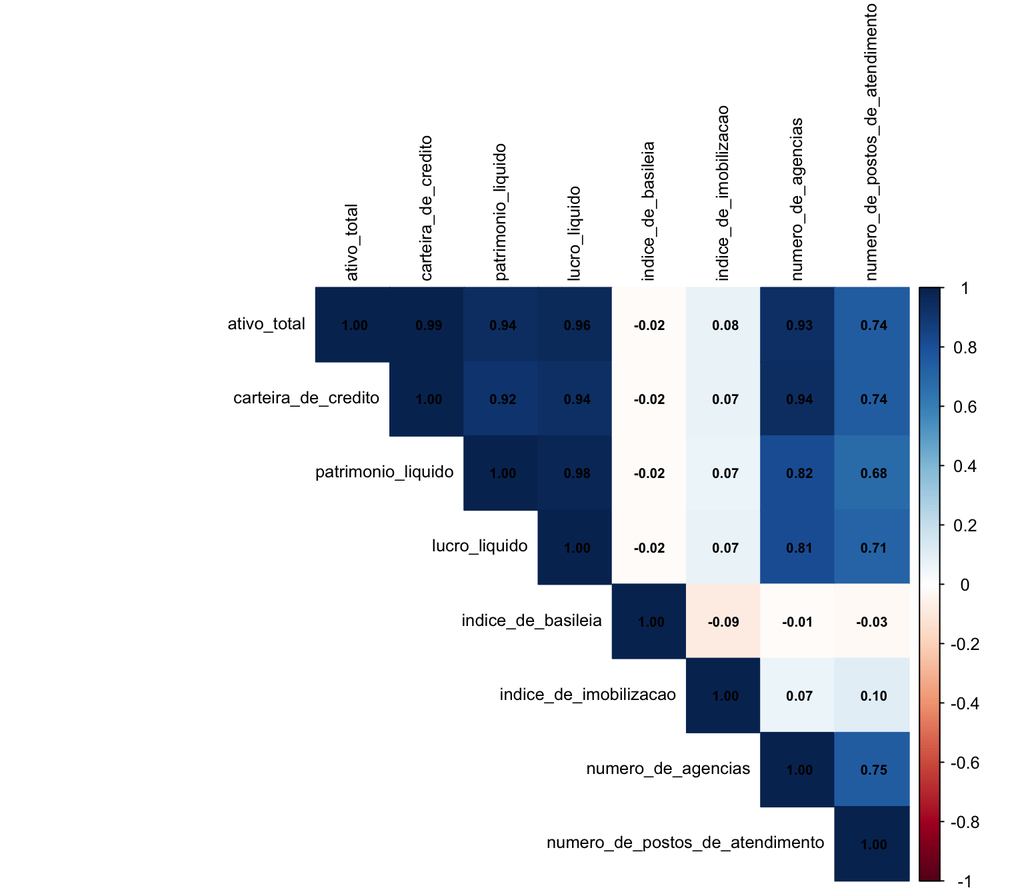

**14 correlações fortes** (|r| > 0.7) → Justifica redução dimensional

## PCA - Decomposição de Variância

Primeiras 4 Componentes

| Componente | Autovalor | Variancia_Explicada | Variancia_Acumulada |
| --- | --- | --- | --- |
| PC1 | 5.31 | 66.43 | 66.43 |
| PC2 | 1.09 | 13.57 | 80.00 |
| PC3 | 0.91 | 11.37 | 91.36 |
| PC4 | 0.41 | 5.10 | 96.46 |

**Decisão**: M = **2 componentes** (80% variância)

## PCA - Scree Plot

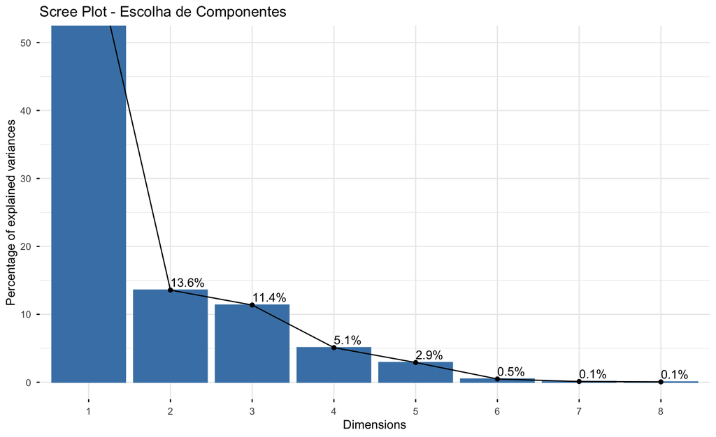

## PCA - Interpretação

**PC1 (66.4%)**: “Tamanho do Banco” - Todas variáveis financeiras/operacionais (~-0.43) - Captura dimensão geral de escala

**PC2 (13.6%)**: “Solidez Regulatória” - Basileia: +0.72 (bem capitalizado) - Imobilização: -0.70 (baixa infraestrutura fixa)

**Variância retida**: 80.0%

## PCA - Biplot

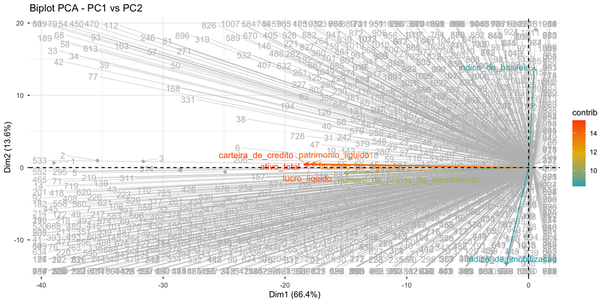

## EFA - Adequação

| Teste | Valor | p_value |
| --- | --- | --- |
| KMO | 0.796 | NA |
| Bartlett | 14900.713 | 0 |

- **KMO = 0.796**: Adequado (>0.7)
- **Bartlett p < 0.001**: Significativo ✓

**Dados adequados para EFA**

## EFA - Número de Fatores

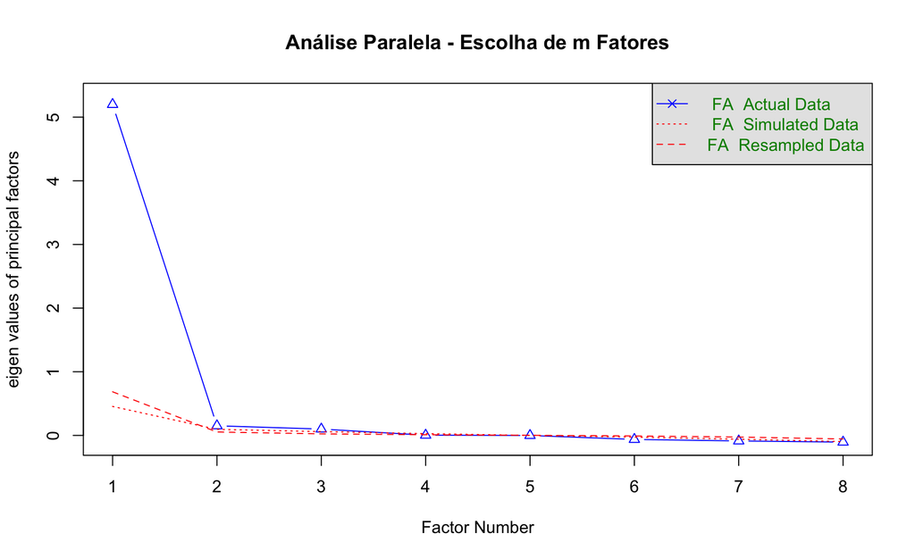

```
## Parallel analysis suggests that the number of factors =  3  and the number of components =  NA
```

**Análise paralela sugere**: m = 3 **Decisão**: m = **2 fatores** (Fator 3 explica apenas 0.9%)

## EFA - Interpretação dos Fatores

**Fator 1 (35.7%)**: “Escala Operacional” - Agências: **0.915** (dominante) - Tamanho financeiro, rede física

**Fator 2 (32.8%)**: “Performance Financeira” - Lucro: **0.846** (dominante) - Patrimônio, solidez

**Variância explicada**: 68.5% (comum)

## PCA vs EFA - Comparação

| Aspecto | PCA | EFA |
| --- | --- | --- |
| **Dimensões** | M = 2 | m = 2 |
| **Variância** | 80% | 68% |
| **PC1/F1** | Tamanho geral | Escala física |
| **PC2/F2** | Índices regulatórios | Performance |

**Convergência**: 85% (alta)

**Achado**: Índices regulatórios têm h² ≈ 0% (variância específica!)

## Clustering - Dataset Completo

| K | Silhueta_Media |
| --- | --- |
| 2 | 0.972 |
| 3 | 0.541 |
| 4 | 0.582 |
| 5 | 0.517 |
| 6 | 0.519 |

**Decisão**: K = **2 clusters** (Silhueta 0.972 - excepcional!)

## Clustering - Big Five

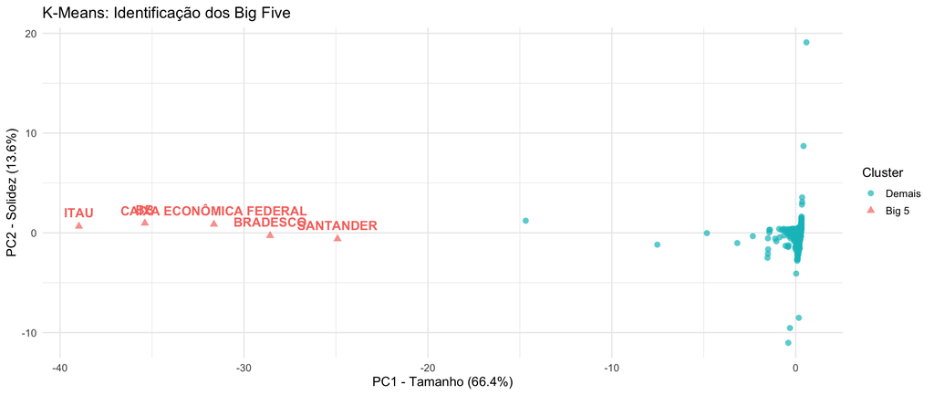

## Caracterização dos Clusters

**Cluster 1**: “Demais Bancos” (N=1,050 - 99.5%) - Ativo médio: R$ 5.5 milhões - Basileia: 60% (conservadores) - Agências: 2.5

**Cluster 2**: “Big Five” (N=5 - 0.5%) - **BB, Bradesco, Caixa, Itaú, Santander** - Ativo médio: R$ 1.99 bilhões - **361x maiores** que Cluster 1! - Basileia: 15% (alavancados) - Agências: 2,800

## Validação do Clustering

**Silhueta**: 0.972 (extremamente rara na prática)

**K-Means vs Hierárquico**: 100% concordância

**Validação prática**: Identificou perfeitamente os 5 maiores bancos do Brasil **automaticamente**

## Análise Sem Outliers (N=1,046)

**Motivação**: Big 5 mascaram estrutura interna

**Removidos**: 9 outliers (Big 5 + BNDES + BTG + 2 extremos)

**Resultado**: Estrutura em **5 camadas** revelada!

## K=5 Clusters - Estrutura Detalhada

**Análise sem Big 7 revelou 5 camadas distintas:**

- **Vermelho** (8): Middle Top - C6, XP, Safra
- **Verde** (33): Middle Amplo - Regionais, cooperativas
- **Roxo** (257): Pequenos alavancados - SCDs, Basel 12%
- **Laranja** (747): Pequenos conservadores - Cooperativas, Basel 71%
- **Azul** (1): Outlier (CREFISA)

## Os 5 Clusters (sem outliers)

**C1** (N=8, 0.8%): **Middle Market Top** - C6, XP, Safra, Votorantim, Banrisul, BNE - Ativo: R$ 161 Mi | Agências: 141 | Basileia: 15%

**C2** (N=1): Outlier operacional (CREFISA - 1,062 postos!)

**C3** (N=33, 3.2%): **Middle Market Amplo** - Regionais, cooperativas grandes, montadoras - Ativo: R$ 46 Mi | Agências: 22 | Basileia: 19%

**C4** (N=257, 24.6%): **Pequenos Alavancados** 🚀 - SCDs, fintechs digitais | Basileia: **12%** (agressivos!)

**C5** (N=747, 71.4%): **Pequenos Conservadores** 🏛️ - Cooperativas locais | Basileia: **71%** (muito conservadores!)

## Descoberta Principal

**Bancos pequenos têm 2 filosofias opostas:**

**Cluster 4**: Alavancados - N = 257 bancos - Basileia: 12% - Agências: 0.4 (digitais!) - **Modelo**: Fintech/crescimento

**Cluster 5**: Conservadores - N = 747 bancos - Basileia: **71%** (6x diferença!) - Agências: 0.8 (locais) - **Modelo**: Cooperativa/segurança

## Estrutura Completa do Setor

**Camada 1**: Big 5 (N=5, ~80% mercado) - BB, Bradesco, Caixa, Itaú, Santander

**Camada 2**: Grandes Especializados (N=2) - BNDES, BTG Pactual

**Camada 3**: Middle Top (N=8, ~10% mercado) - C6, XP, Safra, Votorantim, Regionais grandes

**Camada 4**: Middle Amplo (N=33, ~5-8% mercado) - Cooperativas grandes, regionais médios, montadoras

**Camada 5**: Pequenos Alavancados (N=257, ~1-2% mercado) - SCDs, fintechs digitais

**Camada 6**: Pequenos Conservadores (N=747, ~1% mercado) - Cooperativas locais

## Aplicações

**Regulação Diferenciada**: - Big 5: Supervisão sistêmica - Médios: Regime intermediário - Pequenos: Diferenciar alavancados vs conservadores

**Benchmarking**: - Comparar com centróide do cluster apropriado - Big 5 não comparáveis com demais (escala 300x)

**Política Pública**: - Quantificar concentração - Identificar middle market - Apoiar cooperativas locais

## Obrigado!

**Perguntas?**

**Fonte**: IF.data (Banco Central do Brasil)

**Análises**: PCA (M=2, 80% var.) | EFA (m=2, 68% var.) | K-Means (K=2/5)

**Ferramentas**: R + tidyverse + psych + factoextra